# Lab 6. Modelación no lineal

En este laboratorio, volvemos a analizar los datos de **Wage** considerados en los ejemplos a lo largo de este capítulo, con el fin de ilustrar el hecho de que muchos de los complejos procedimientos de ajuste no lineales discutidos pueden ser fácilmente implementados en R. Comenzamos cargando la librería **ISLR**, que contiene los datos.

```r
library (ISLR)
attach (Wage)
summary (Wage)
```

```
##       year           age                     maritl           race
##  Min.   :2003   Min.   :18.00   1. Never Married: 648   1. White:2480
##  1st Qu.:2004   1st Qu.:33.75   2. Married      :2074   2. Black: 293
##  Median :2006   Median :42.00   3. Widowed      :  19   3. Asian: 190
##  Mean   :2006   Mean   :42.41   4. Divorced     : 204   4. Other:  37
##  3rd Qu.:2008   3rd Qu.:51.00   5. Separated    :  55
##  Max.   :2009   Max.   :80.00
##
##               education                     region               jobclass
##  1. < HS Grad      :268   2. Middle Atlantic   :3000   1. Industrial :1544
##  2. HS Grad        :971   1. New England       :   0   2. Information:1456
##  3. Some College   :650   3. East North Central:   0
##  4. College Grad   :685   4. West North Central:   0
##  5. Advanced Degree:426   5. South Atlantic    :   0
##                           6. East South Central:   0
##                           (Other)              :   0
##             health      health_ins      logwage           wage
##  1. <=Good     : 858   1. Yes:2083   Min.   :3.000   Min.   : 20.09
##  2. >=Very Good:2142   2. No : 917   1st Qu.:4.447   1st Qu.: 85.38
##                                      Median :4.653   Median :104.92
##                                      Mean   :4.654   Mean   :111.70
##                                      3rd Qu.:4.857   3rd Qu.:128.68
##                                      Max.   :5.763   Max.   :318.34
##
```

### 1. Regresión Polinómica y Funciones de paso

Para este ejemplo ajustaremos a un modelo lineal, usando la función **lm()**, para predecir el salario usando un polinomio de cuarto grado en **age: poly(age,4)**. El comando **poly()** nos permite evitar tener que escribir una fórmula larga. El comando es el siguiente:

```r
#Predecir el salario con un polinomio de cuarto grado,función poli corre la variable lineal. x2,x3 y x4

fit<-lm(wage~poly(age,4), data=Wage)
summary(fit)
```

```
##
## Call:
## lm(formula = wage ~ poly(age, 4), data = Wage)
##
## Residuals:
##     Min      1Q  Median      3Q     Max
## -98.707 -24.626  -4.993  15.217 203.693
##
## Coefficients:
##                Estimate Std. Error t value Pr(>|t|)
## (Intercept)    111.7036     0.7287 153.283  < 2e-16 ***
## poly(age, 4)1  447.0679    39.9148  11.201  < 2e-16 ***
## poly(age, 4)2 -478.3158    39.9148 -11.983  < 2e-16 ***
## poly(age, 4)3  125.5217    39.9148   3.145  0.00168 **
## poly(age, 4)4  -77.9112    39.9148  -1.952  0.05104 .
## ---
## Signif. codes:  0 '***' 0.001 '**' 0.01 '*' 0.05 '.' 0.1 ' ' 1
##
## Residual standard error: 39.91 on 2995 degrees of freedom
## Multiple R-squared:  0.08626,    Adjusted R-squared:  0.08504
## F-statistic: 70.69 on 4 and 2995 DF,  p-value: < 2.2e-16
```

La función devuelve una matriz cuyas columnas son una base de *polinomios ortogonales*, lo que esencialmente significa que cada columna es una combinación lineal de las variables **$age$**, **$age^{2}$**, **$age^{3}$** y **$age^{4}$**.

Ahora creamos una cuadrícula de valores para **age** en la que queremos predicciones, y luego llamamos a la función genérica **predict()**, especificando que también queremos errores estándar.

```r
#Range para obtener el rango y lo guardamos en agelims

agelims<-range(age)
agelims
```

```
## [1] 18 80
```

```r
#Seq es para crear una secuencia para el rango
age.grid<-seq (from=agelims [1], to=agelims [2])
age.grid
```

```
##  [1] 18 19 20 21 22 23 24 25 26 27 28 29 30 31 32 33 34 35 36 37 38 39 40 41 42
## [26] 43 44 45 46 47 48 49 50 51 52 53 54 55 56 57 58 59 60 61 62 63 64 65 66 67
## [51] 68 69 70 71 72 73 74 75 76 77 78 79 80
```

```r
#Newdata=list, estamos corriendo la secuencia que creamos
#Se = true es que nos considere los estandar errors
preds<-predict(fit, newdata=list(age=age.grid),se=TRUE)
preds
```

```
## $fit
##         1         2         3         4         5         6         7         8
##  51.93145  58.49674  64.57188  70.18273  75.35440  80.11122  84.47676  88.47380
##         9        10        11        12        13        14        15        16
##  92.12437  95.44973  98.47038 101.20601 103.67560 105.89731 107.88856 109.66599
##        17        18        19        20        21        22        23        24
## 111.24548 112.64214 113.87029 114.94351 115.87459 116.67557 117.35770 117.93148
##        25        26        27        28        29        30        31        32
## 118.40662 118.79210 119.09608 119.32598 119.48846 119.58939 119.63388 119.62627
##        33        34        35        36        37        38        39        40
## 119.57013 119.46827 119.32271 119.13473 118.90481 118.63269 118.31733 117.95691
##        41        42        43        44        45        46        47        48
## 117.54885 117.08980 116.57566 116.00152 115.36174 114.64988 113.85877 112.98043
##        49        50        51        52        53        54        55        56
## 112.00613 110.92638 109.73090 108.40865 106.94784 105.33588 103.55943 101.60437
##        57        58        59        60        61        62        63
##  99.45583  97.09815  94.51491  91.68893  88.60223  85.23611  81.57105
##
## $se.fit
##         1         2         3         4         5         6         7         8
##  5.298268  4.370763  3.592101  2.955813  2.455588  2.083260  1.825676  1.662329
##         9        10        11        12        13        14        15        16
##  1.566864  1.512533  1.477572  1.447355  1.413769  1.373549  1.326690  1.275230
##        17        18        19        20        21        22        23        24
##  1.222382  1.171865  1.127324  1.091786  1.067171  1.053981  1.051263  1.056899
##        25        26        27        28        29        30        31        32
##  1.068100  1.081939  1.095809  1.107729  1.116537  1.121992  1.124827  1.126747
##        33        34        35        36        37        38        39        40
##  1.130363  1.139015  1.156439  1.186260  1.231415  1.293640  1.373218  1.469069
##        41        42        43        44        45        46        47        48
##  1.579082  1.700568  1.830715  1.966988  2.107496  2.251362  2.399124  2.553187
##        49        50        51        52        53        54        55        56
##  2.718307  2.902040  3.115018  3.370894  3.685814  4.077417  4.563601  5.161438
##        57        58        59        60        61        62        63
##  5.886530  6.752911  7.773327  8.959688 10.323512 11.876272 13.629642
##
## $df
## [1] 2995
##
## $residual.scale
## [1] 39.91479
```

```r
#Se utilizan las predicciones de fit
se.bands<-cbind(preds$fit + 2*preds$se.fit, preds$fit - 2*preds$se.fit)
se.bands
```

```
##         [,1]      [,2]
## 1   62.52799  41.33491
## 2   67.23827  49.75522
## 3   71.75608  57.38768
## 4   76.09436  64.27111
## 5   80.26558  70.44323
## 6   84.27774  75.94470
## 7   88.12811  80.82540
## 8   91.79845  85.14914
## 9   95.25810  88.99064
## 10  98.47480  92.42467
## 11 101.42552  95.51523
## 12 104.10072  98.31130
## 13 106.50313 100.84806
## 14 108.64441 103.15021
```

[output cut: 49 more lines]

Finalmente, ploteamos los datos y añadimos el ajuste del polinomio de grado 4.

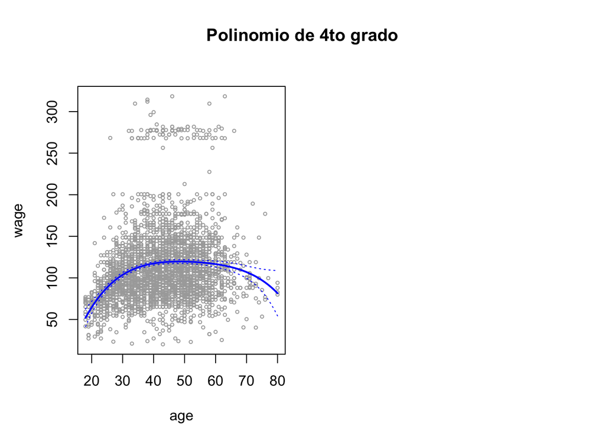

```r
#Mar y oma es una cuestión para los margenes del row
#Par(mfro2=c(1,2) indica como quieres que te la presente
par(mfrow =c(1,2), mar=c(4.5 ,4.5 ,1 ,1), oma=c(0,0,4,0))
#Ploteo y puntos
plot(age, wage, xlim=agelims, cex =.5, col="darkgrey")
#Para el título
title ("Polinomio de 4to grado", outer =T)
#Líneas apra las gráficas
lines(age.grid, preds$fit, lwd=2, col=" blue")
#Líneas de nuestras bandas
matlines (age.grid, se.bands, lwd=1, col=" blue", lty =3)
```

Aquí los argumentos **mar** y **oma** de **par()** nos permiten controlar los márgenes del plot, y la función **title()** crea un título de figura que abarca ambos ploteos.

Al realizar una regresión polinómica debemos decidir el grado del polinomio a utilizar. Una forma de hacerlo es usando pruebas de hipótesis. En este caso ajustaremos modelos que van desde el polinomio lineal hasta un grado 5 y tratamos de determinar el modelo más simple que sea suficiente para explicar la relación entre **wage** y **age**. Utilizamos la función **anova()**, que realiza un *análisis de varianza* (ANOVA por sus siglas en inglés, utilizando una prueba F) para probar la hipótesis nula de que un modelo M1 es suficiente para explicar los datos frente a la hipótesis alternativa de que se requiere un modelo M2 más complejo. Para poder utilizar la función **anova()**, M1 y M2 deben ser modelos *anidados*: los predictores en M1 deben ser un subconjunto de los predictores en M2. En este caso, ajustamos cinco modelos diferentes y comparamos secuencialmente el modelo más simple con el más complejo.

```r
#Podría ser nuestra hipótesis nula el fit.1
fit.1 <- lm(wage~age,data=Wage)
fit.2 <- lm(wage~poly(age,2),data=Wage)
fit.3 <- lm(wage~poly(age,3),data=Wage)
fit.4 <- lm(wage~poly(age,4),data=Wage)
fit.5 <- lm(wage~poly(age,5),data=Wage)
#Análisis de varianza para todos los modelos
anova(fit.1, fit.2, fit.3, fit.4, fit.5)
```

```
## Analysis of Variance Table
##
## Model 1: wage ~ age
## Model 2: wage ~ poly(age, 2)
## Model 3: wage ~ poly(age, 3)
## Model 4: wage ~ poly(age, 4)
## Model 5: wage ~ poly(age, 5)
##   Res.Df     RSS Df Sum of Sq        F    Pr(>F)
## 1   2998 5022216
## 2   2997 4793430  1    228786 143.5931 < 2.2e-16 ***
## 3   2996 4777674  1     15756   9.8888  0.001679 **
## 4   2995 4771604  1      6070   3.8098  0.051046 .
## 5   2994 4770322  1      1283   0.8050  0.369682
## ---
## Signif. codes:  0 '***' 0.001 '**' 0.01 '*' 0.05 '.' 0.1 ' ' 1
```

```r
#Estas comparando y haciendo pruebas de hipótesis
```

El *p-value* que compara el **Modelo 1** lineal con el **Modelo 2** cuadrático es esencialmente cero (<$10^{-16}$), lo que indica que un ajuste lineal no es suficiente. De manera similar, el *p-value* que compara el **Modelo 2** cuadrático con el **Modelo 3** cúbico es muy bajo (0,001679), por lo que el ajuste cuadrático también es insuficiente. El *p-value* que compara los polinomios cúbicos y de grado 4, **Modelo 3** y **Modelo 4**, es aproximadamente el 5% mientras que el polinomio de grado 5 **Modelo 5** parece innecesario porque su *p-value* es 0.37. Por lo tanto, un polinomio cúbico o de grado 4 parece proporcionar un ajuste razonable a los datos, pero no se justifican los modelos de orden inferior o superior.

A continuación consideramos la tarea de predecir si un individuo gana más de 250.000 dólares al año. Procedemos de la misma manera que antes, excepto que primero creamos el vector de respuesta apropiado, y luego aplicamos la función **glm()** usando **family=“binomial”** para ajustar un modelo de regresión logística polinómica.

```r
#Regresión logística polinómica
#Estamos sacando los datos mayores a 250 en wage
#Utilizando family=binomial le indicamos a la función que la respuesta que esperamos es binomial
fit<-glm(I(wage >250)~poly(age,4), data=Wage, family=binomial)
```

Obsérvese que volvemos a utilizar el **I()** a forma de envoltorio, para crear esta variable de respuesta binaria sobre la marcha. La expresión **wage>250** se evalúa a una variable lógica que contiene **TRUE**s y **FALSE**s, que **glm()** coacciona a binario poniendo los **TRUE**s a 1 y los **FALSE**s a 0.

Una vez más, hacemos predicciones usando la función **predict()**.

```r
#Predecir la probabilidad de que alguien tenga ese sueldo
preds<-predict(fit, newdata=list(age=age.grid), se=T)
```

Sin embargo, el cálculo de los intervalos de confianza está ligeramente más complicado que en el caso de la regresión lineal. El tipo de predicción por defecto para un modelo **glm()** es **type=“link”**, que es lo que usamos aquí. Esto significa que obtenemos predicciones para el logit: es decir, hemos ajustado un modelo de la forma

$$log\frac{Pr(Y=1|X)}{1-Pr(Y=1|X)}=X\beta,$$

y las predicciones que se han hecho son de la forma $X\hat{\beta}$ que se ha hecho. Los errores estándar dados también son de esta forma. Para obtener los intervalos de confianza para Pr($Y$ = 1|$X$), usamos la transformación

$$Pr(Y=1|X)=\frac{exp(X\beta)}{1+exp(X\beta)}.$$

```r
#Esta es la fórmula de arriba
pfit<-exp(preds$fit)/(1 + exp( preds$fit ))
se.bands.logit <- cbind(preds$fit + 2*preds$se.fit, preds$fit - 2*preds$se.fit)
se.bands <- exp(se.bands.logit)/(1+ exp(se.bands.logit))
```

Finalmente, se grafica de la siguiente manera:

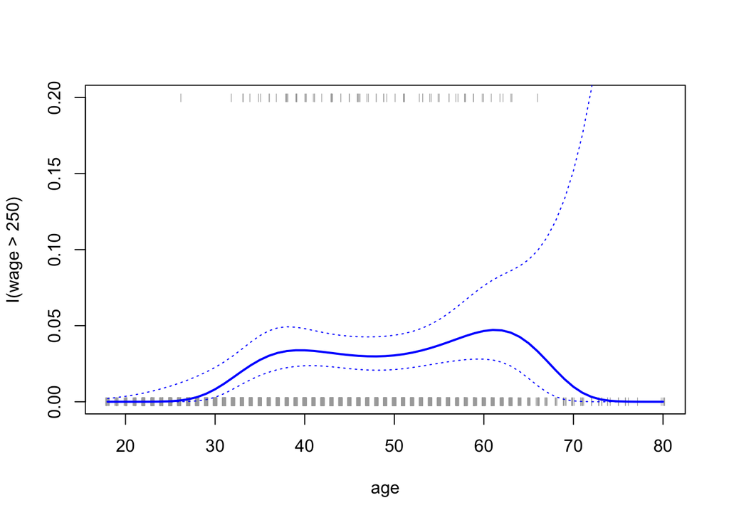

```r
plot(age, I(wage>250), xlim=agelims, type="n", ylim=c(0,0.2))
points(jitter(age), I((wage>250)/5), cex=0.5, pch="|", col="darkgrey")
lines(age.grid, pfit, lwd=2, col="blue")
matlines(age.grid, se.bands, lwd=1, col="blue", lty =3)
```

Para ajustar una función de paso, usamos la función **cut()**.

```r
#Función cut es para dividir la variable age en 4 categorías
table(cut(age,4))
```

```
##
## (17.9,33.5]   (33.5,49]   (49,64.5] (64.5,80.1]
##         750        1399         779          72
```

```r
fit<-lm(wage~cut(age,4), data=Wage)
coef(summary(fit))
```

```
##                         Estimate Std. Error   t value     Pr(>|t|)
## (Intercept)            94.158392   1.476069 63.789970 0.000000e+00
## cut(age, 4)(33.5,49]   24.053491   1.829431 13.148074 1.982315e-38
## cut(age, 4)(49,64.5]   23.664559   2.067958 11.443444 1.040750e-29
## cut(age, 4)(64.5,80.1]  7.640592   4.987424  1.531972 1.256350e-01
```

Aquí **cut()** automáticamente escogió los puntos de corte a los 33.5, 49 y 64.5 años de edad. También podríamos haber especificado nuestros propios puntos de corte directamente usando la opción de breaks. La función **cut()** devuelve una variable categórica ordenada; la función **lm()** crea entonces un conjunto de variables ficticias para su uso en la regresión. La categoría **age<33.5** se deja fuera, por lo que el coeficiente del intercepto de $94,160 dólares puede interpretarse como el salario medio para los menores de 33.5 años, y los otros coeficientes pueden interpretarse como el salario adicional medio para los de los otros grupos de edad. Podemos producir predicciones y gráficos como lo hicimos en el caso del ajuste polinómico.

### 2. Splines

Para ajustar las regresiones splines en R, usamos la libreria de **splines**. las regresiones splines pueden ser ajustadas construyendo una matriz apropiada de funciones base. La función **bs()** genera toda la matriz de funciones base para splines con el conjunto de nodos especificado. Por defecto, se producen splines cúbicos. El ajuste de **wage** a **age** mediante una regresión spline es sencillo:

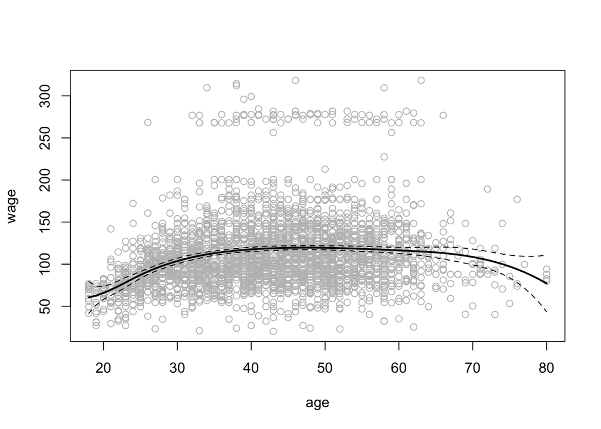

```r
library(splines)
#bs genera todas las funciones base para la regresión
fit<-lm(wage~bs(age, knots=c(25, 40, 60)), data=Wage)
pred<-predict(fit, newdata=list(age=age.grid), se=T)
plot(age, wage, col="gray")
lines(age.grid, pred$fit ,lwd =2)
lines(age.grid, pred$fit + 2*pred$se, lty="dashed")
lines(age.grid, pred$fit - 2*pred$se, lty="dashed")
```

Aquí tenemos nodos preespecificados a las edades de 25, 40 y 60 años. Esto produce un spline con seis funciones básicas. (Recordemos que un spline cúbico con tres nodos tiene siete grados de libertad; estos grados de libertad son usados por un intercepto, más seis funciones básicas). También podríamos usar la opción **df** para producir una spline con nodos en cuantiles uniformes de los datos.

```r
#Df produce una spline con nodos en cuantiles uniformaes de los datos
dim(bs(age, knots=c(25, 40, 60)))
```

```
## [1] 3000    6
```

```r
#indicamos cuantos grados de libertad queremos en nuestra spline
dim(bs(age, df=6))
```

```
## [1] 3000    6
```

```r
attr(bs(age, df=6), "knots")
```

```
##   25%   50%   75%
## 33.75 42.00 51.00
```

En este caso R elige nodos a las edades de 33.8, 42.0 y 51.0, que corresponden a los percentiles 25, 50 y 75 de la **age**. La función **bs()** también tiene un argumento de **degree**, por lo que podemos ajustar splines de cualquier grado, en lugar del grado por defecto de 3 (que produce un spline cúbico).

Para poder ajustar un spline natural, usamos la función **ns()**. Aquí ajustamos un spline natural con cuatro grados de libertad.

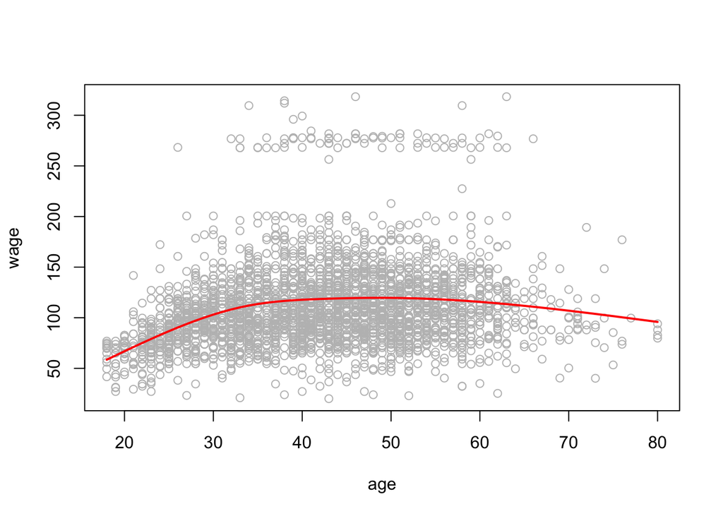

```r
#Para una spline natural usamos sn
fit2<-lm(wage~ns(age, df=4), data=Wage)
#Predict nos sirve para ajustar a un modelo predefinido hace una predicción de esa respuesta para probar y hacer predicciones con otros datos
pred2<-predict(fit2, newdata=list(age=age.grid), se=T)
plot(age, wage, col="gray")
lines(age.grid, pred2$fit, col="red", lwd =2)
```

Al igual que con la función **bs()**, podríamos en cambio especificar los **knots** directamente usando la opción de nodos.

```r
plot(age, wage, xlim=agelims, cex =.5, col ="darkgrey")
title("Smoothing Spline")
#Smooth.spline lo utilizamos para
fit<-smooth.spline(age, wage, df =16)
#Cv=true para indicar que realice una validación cruzada
fit2<-smooth.spline(age, wage, cv=TRUE)
fit2$df
```

```
## [1] 6.794596
```

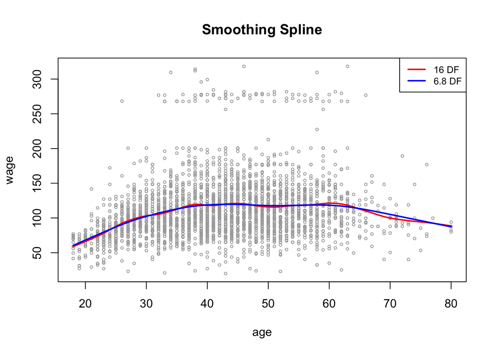

```r
lines(fit, col ="red", lwd =2)
lines(fit2, col ="blue", lwd =2)
legend("topright", legend=c("16 DF", "6.8 DF"), col=c("red","blue"), lty =1, lwd =2, cex =.8)
```

Fíjense que en la primera llamada a **smooth.spline()**, especificamos **df=16**. La función entonces determina qué valor de $\lambda$ lleva a 16 grados de libertad. En la segunda llamada a **smooth.spline()**, seleccionamos el nivel de suavidad por validación cruzada; esto resulta en un valor de $\lambda$ que da 6,8 grados de libertad.

### 3. GAMs (Generalized Additive Models)

Ahora ajustamos un GAM para predecir el **wage** usando las funciones spline naturales de **year** y **age**, tratando **education** como un predictor cualitativo. Dado que esto es sólo un gran modelo de regresión lineal que utiliza una elección apropiada de funciones base, podemos simplemente hacer esto utilizando la función **lm()**.

```r
gam1<-lm(wage~ns(year, 4) + ns(age, 5) + education, data=Wage)
```

Ahora ajustamos el modelo $wage=\beta_0+f_1(year)+f_2(age)+f_3(education)+\epsilon$ usando splines suavizados en lugar de splines naturales. Para poder ajustar tipos más generales de GAM, utilizando splines suavizados u otros componentes que no pueden ser expresados en términos de funciones base y luego ajustar usando la regresión de mínimos cuadrados, necesitaremos usar la librería **gam** en R.

La función **s()**, que forma parte de la libraría **gam**, se utiliza para indicar que nos gustaría utilizar un spline suavizado. Especificamos que la función de **year** debe tener 4 grados de libertad, y que la función de **age** tendrá 5 grados de libertad. Como **education** es cualitativa, la dejamos como está, y se convierte en cuatro variables dummy. Utilizamos la función **gam()** para ajustar un GAM usando estos componentes. Todos los términos en el modelo se ajustan simultáneamente, tomándose en cuenta unos a otros para explicar la respuesta.

```r
library(gam)
#Para ajustar una GAM
gam.m3<-gam(wage~s(year, 4) + s(age, 5) + education, data=Wage)
```

Para graficar simplemente llamamos a la función **plot()**:

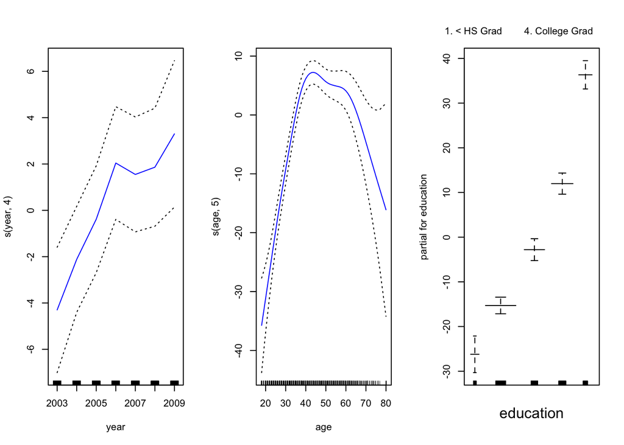

```r
#Muestra 3 modelos
par(mfrow =c(1,3))
plot(gam.m3, se=TRUE ,col ="blue ")
```

La función genérica **plot()** reconoce que **gam.m3** es un objeto de la clase **gam**, e invoca el método **plot.Gam()** apropiado. Convenientemente, aunque **gam1** no es de la clase **gam** sino de la clase **lm**, podemos *seguir usando* **plot.Gam()** en él.

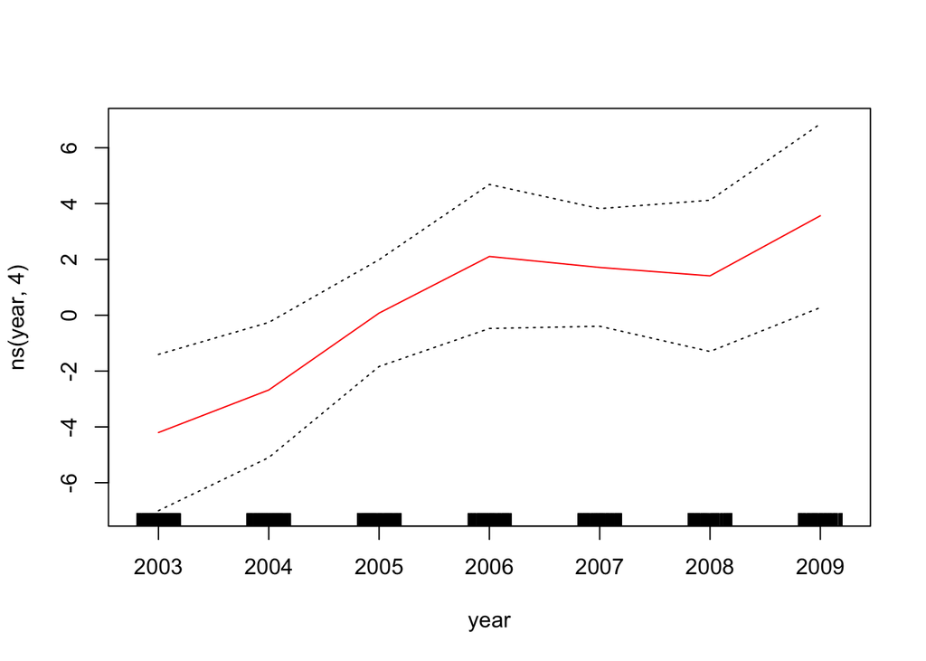

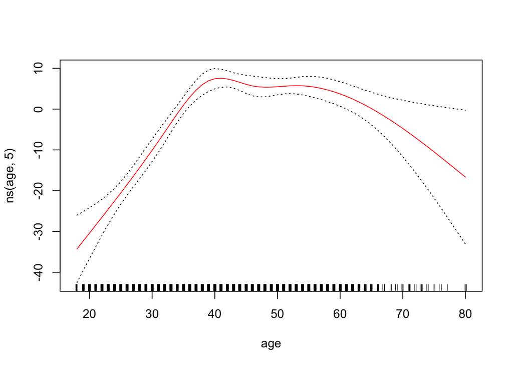

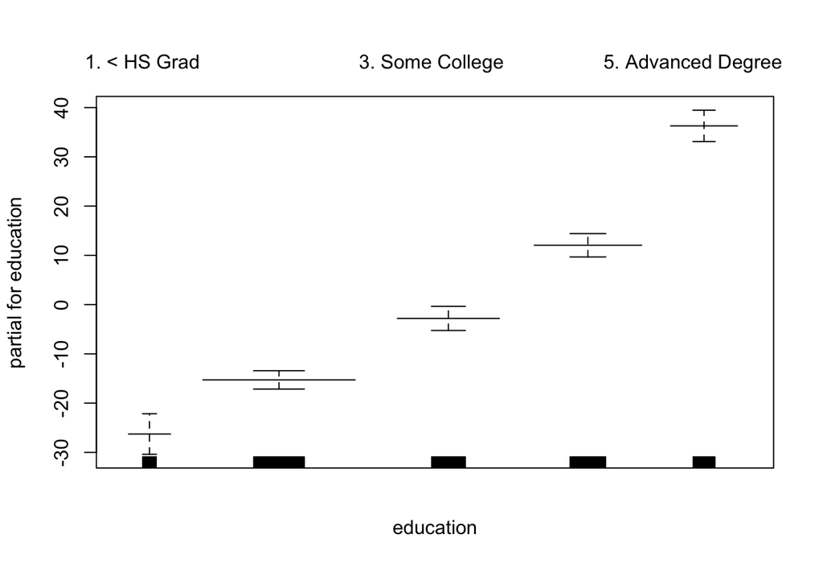

```r
#Obtener cada gráfica por separado
plot.Gam(gam1, se=TRUE, col ="red")
```

Noten que tuvimos que usar **plot.Gam()** en lugar de la función genérica **plot()**.

En estos gráficos, la función de **year** parece bastante lineal. Podemos realizar una serie de pruebas de ANOVA para determinar cuál de estos tres modelos es el mejor: un GAM que excluye **year** (M1), un GAM que utiliza una función lineal de **year** (M2), o un GAM que utiliza una función de spline de **year** (M3).

```r
#Función s que es spline suave
gam.m1<-gam(wage~s(age, 5) + education, data=Wage)
#lineal con grados de libertad
gam.m2<-gam(wage~year+s(age, 5) + education, data=Wage)
#splinesuave
gam.m3<-gam(wage~s(year, 4) + s(age, 5) + education, data=Wage)
anova(gam.m1, gam.m2, gam.m3, test="F")
```

```
## Analysis of Deviance Table
##
## Model 1: wage ~ s(age, 5) + education
## Model 2: wage ~ year + s(age, 5) + education
## Model 3: wage ~ s(year, 4) + s(age, 5) + education
##   Resid. Df Resid. Dev Df Deviance       F    Pr(>F)
## 1      2990    3711731
## 2      2989    3693842  1  17889.2 14.4771 0.0001447 ***
## 3      2986    3689770  3   4071.1  1.0982 0.3485661
## ---
## Signif. codes:  0 '***' 0.001 '**' 0.01 '*' 0.05 '.' 0.1 ' ' 1
```

```r
#siempre te quedas con el modelo que siga rechazando la hipótesis nula
```

Encontramos que hay pruebas convincentes de que un GAM con una función lineal de **year** es mejor que un GAM que no incluye **year** en absoluto ( *p-value*=0.00014 ). Sin embargo, no hay evidencia de que se necesite una función no lineal de **year** ( *p-value*=0.349 ). En otras palabras, en base a los resultados de este ANOVA, se prefiere M2.

La función **summary()** produce un resumen del ajuste del GAM.

```r
summary(gam.m2)
```

```
##
## Call: gam(formula = wage ~ year + s(age, 5) + education, data = Wage)
## Deviance Residuals:
##      Min       1Q   Median       3Q      Max
## -119.959  -19.647   -3.199   13.969  213.562
##
## (Dispersion Parameter for gaussian family taken to be 1235.812)
##
##     Null Deviance: 5222086 on 2999 degrees of freedom
## Residual Deviance: 3693842 on 2989 degrees of freedom
## AIC: 29885.06
##
## Number of Local Scoring Iterations: NA
##
## Anova for Parametric Effects
##             Df  Sum Sq Mean Sq F value    Pr(>F)
## year         1   27154   27154  21.973  2.89e-06 ***
## s(age, 5)    1  194535  194535 157.415 < 2.2e-16 ***
## education    4 1069081  267270 216.271 < 2.2e-16 ***
## Residuals 2989 3693842    1236
## ---
## Signif. codes:  0 '***' 0.001 '**' 0.01 '*' 0.05 '.' 0.1 ' ' 1
##
## Anova for Nonparametric Effects
##             Npar Df Npar F     Pr(F)
## (Intercept)
## year
## s(age, 5)         4  32.46 < 2.2e-16 ***
## education
## ---
## Signif. codes:  0 '***' 0.001 '**' 0.01 '*' 0.05 '.' 0.1 ' ' 1
```

Para ajustar una regresión logística GAM, utilizamos una vez más la función **I()** en la construcción de la variable de respuesta binaria, y establecemos **family=binomial**.

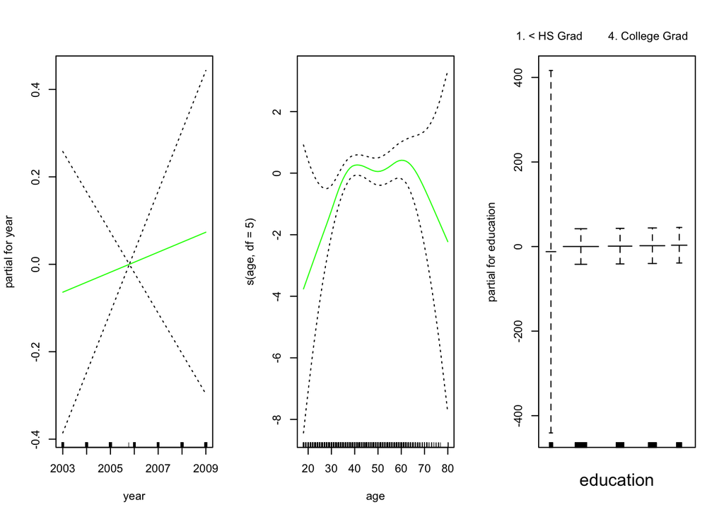

```r
#Al hacer un modelo logit se agrega family=binomial
gam.lr<-gam(I(wage >250)~year+s(age, df=5) + education, family =binomial, data=Wage)
par(mfrow=c(1,3))
plot(gam.lr, se=T, col="green")
```

Es fácil ver que no hay personas con altos ingresos en la categoría **$<HS$**:

```r
table(education, I(wage>250))
```

```
##
## education            FALSE TRUE
##   1. < HS Grad         268    0
##   2. HS Grad           966    5
##   3. Some College      643    7
##   4. College Grad      663   22
##   5. Advanced Degree   381   45
```

### 4. Resuelve

A continuación nos daremos a la tarea de predecir si un individuo gana más de 125,000 dólares al año. Primero creamos el vector de respuesta apropiado, y luego aplicamos la función **glm()** usando **family=“binomial”** para ajustar un modelo de regresión logística polinómica.

```r
library(ISLR)
attach(Wage)
summary(Wage)
```

```
##       year           age                     maritl           race
##  Min.   :2003   Min.   :18.00   1. Never Married: 648   1. White:2480
##  1st Qu.:2004   1st Qu.:33.75   2. Married      :2074   2. Black: 293
##  Median :2006   Median :42.00   3. Widowed      :  19   3. Asian: 190
##  Mean   :2006   Mean   :42.41   4. Divorced     : 204   4. Other:  37
##  3rd Qu.:2008   3rd Qu.:51.00   5. Separated    :  55
##  Max.   :2009   Max.   :80.00
##
##               education                     region               jobclass
##  1. < HS Grad      :268   2. Middle Atlantic   :3000   1. Industrial :1544
##  2. HS Grad        :971   1. New England       :   0   2. Information:1456
##  3. Some College   :650   3. East North Central:   0
##  4. College Grad   :685   4. West North Central:   0
##  5. Advanced Degree:426   5. South Atlantic    :   0
##                           6. East South Central:   0
##                           (Other)              :   0
##             health      health_ins      logwage           wage
##  1. <=Good     : 858   1. Yes:2083   Min.   :3.000   Min.   : 20.09
##  2. >=Very Good:2142   2. No : 917   1st Qu.:4.447   1st Qu.: 85.38
##                                      Median :4.653   Median :104.92
##                                      Mean   :4.654   Mean   :111.70
##                                      3rd Qu.:4.857   3rd Qu.:128.68
##                                      Max.   :5.763   Max.   :318.34
##
```

```r
#Para 125,000 dólares
fitT<- glm(I(wage>125)~poly(age,4), data=Wage, family=binomial)
```

Realice predicciones usando la función **predict()**.

```r
agelimsT<-range(age)
agelimsT
```

```
## [1] 18 80
```

```r
age.gridT<-seq (from=agelimsT [1], to=agelimsT [2])
predsT<- predict(fitT, newdata=list(age=age.gridT), se=T)
```

Calcule los intervalos de confianza

```r
conffitT<-exp(predsT$fit)/(1+exp(predsT$fit))
se.bands.logit <- cbind(predsT$fit + 2*predsT$se.fit, predsT$fit - 2*predsT$se.fit)
se.bands <- exp(se.bands.logit)/(1+ exp(se.bands.logit))
```

Finalmente, grafica:

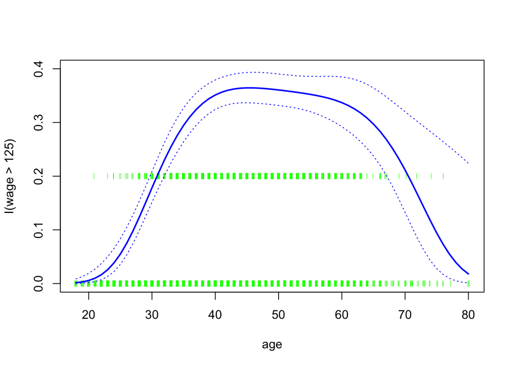

```r
plot(age, I(wage>125), xlim=agelimsT, type="n", ylim=c(0,0.40))
points(jitter(age), I((wage>125)/5), cex=0.5, pch="|", col="green")
lines(age.gridT, conffitT, lwd=2, col="blue")
matlines(age.gridT, se.bands, lwd=1, col="blue", lty =3)
```